# wine_report

2022-06-15

## Data set informattion

we are going to preform the Exploratory Data Analysis techniques on the Red wine data set.

Attribute Information: The Variables are : 1 - fixed acidity 2 - volatile acidity 3 - citric acid 4 - residual sugar 5 - chlorides 6 - free sulfur dioxide 7 - total sulfur dioxide 8 - density 9 - pH 10 - sulphates 11 - alcohol 12 - quality

####Import libraries and load dataset

```r
#Import libraries

install.packages('memisc')
```

```r
install.packages('ggplot2')
install.packages('gridExtra')
install.packages("RColorBrewer")
install.packages("psych")
library(gridExtra)
library(grid)
library(dplyr)
library(GGally)
library(scales)
library(ggpubr)
library(tidyverse)
library(readxl)
library(factoextra)
library(ggplot2)
library(corrplot)
library(factoextra)
library(tidyr)
library(nnet)
library(rpart)
library(janitor)
library(here)
library(kableExtra)
#load dataset using here package

#Uploading the data
red_wine<-read.csv(here("data/winequality-red.csv"))
fixed.acidity<-read.csv(here("data/winequality-red.csv"))
alcohol<-read.csv(here("data/winequality-red.csv"))
rating<-read.csv(here("data/winequality-red.csv"))
citric.acid<-read.csv(here("data/winequality-red.csv"))
volatile.acidity<-read.csv(here("data/winequality-red.csv"))
residual.sugar<-read.csv(here("data/winequality-red.csv"))
chlorides<-read.csv(here("data/winequality-red.csv"))
free.sulfur.dioxide<-read.csv(here("data/winequality-red.csv"))
density<-read.csv(here("data/winequality-red.csv"))
total.sulfur.dioxide<-read.csv(here("data/winequality-red.csv"))
pH<-read.csv(here("data/winequality-red.csv"))
sulphates<-read.csv(here("data/winequality-red.csv"))
quality<-read.csv(here("data/winequality-red.csv"))
```

####Display the data

```r
knitr::kable(head(red_wine[, 1:12]), "pipe")
```

| fixed.acidity | volatile.acidity | citric.acid | residual.sugar | chlorides | free.sulfur.dioxide | total.sulfur.dioxide | density | pH | sulphates | alcohol | quality |
| --- | --- | --- | --- | --- | --- | --- | --- | --- | --- | --- | --- |
| 7.4 | 0.70 | 0.00 | 1.9 | 0.076 | 11 | 34 | 0.9978 | 3.51 | 0.56 | 9.4 | 5 |
| 7.8 | 0.88 | 0.00 | 2.6 | 0.098 | 25 | 67 | 0.9968 | 3.20 | 0.68 | 9.8 | 5 |
| 7.8 | 0.76 | 0.04 | 2.3 | 0.092 | 15 | 54 | 0.9970 | 3.26 | 0.65 | 9.8 | 5 |
| 11.2 | 0.28 | 0.56 | 1.9 | 0.075 | 17 | 60 | 0.9980 | 3.16 | 0.58 | 9.8 | 6 |
| 7.4 | 0.70 | 0.00 | 1.9 | 0.076 | 11 | 34 | 0.9978 | 3.51 | 0.56 | 9.4 | 5 |
| 7.4 | 0.66 | 0.00 | 1.8 | 0.075 | 13 | 40 | 0.9978 | 3.51 | 0.56 | 9.4 | 5 |

####Cleaning the data set names we are going to use clean_names() function from the janitor package.

```r
#cleaning the data set names
 red_wine <-clean_names(red_wine)
 head(red_wine)
```

```
##   fixed_acidity volatile_acidity citric_acid residual_sugar chlorides
## 1           7.4             0.70        0.00            1.9     0.076
## 2           7.8             0.88        0.00            2.6     0.098
## 3           7.8             0.76        0.04            2.3     0.092
## 4          11.2             0.28        0.56            1.9     0.075
## 5           7.4             0.70        0.00            1.9     0.076
## 6           7.4             0.66        0.00            1.8     0.075
##   free_sulfur_dioxide total_sulfur_dioxide density  p_h sulphates alcohol
## 1                  11                   34  0.9978 3.51      0.56     9.4
## 2                  25                   67  0.9968 3.20      0.68     9.8
## 3                  15                   54  0.9970 3.26      0.65     9.8
## 4                  17                   60  0.9980 3.16      0.58     9.8
## 5                  11                   34  0.9978 3.51      0.56     9.4
## 6                  13                   40  0.9978 3.51      0.56     9.4
##   quality
## 1       5
## 2       5
## 3       5
## 4       6
## 5       5
## 6       5
```

After we clean the data set,Lets have a look at the data set dimensions and Let us check the data types of each attribute.

```r
# List red_wine data set column names, types and a subset of values

str_redwine <- str(red_wine)
```

```
## 'data.frame':    1599 obs. of  12 variables:
##  $ fixed_acidity       : num  7.4 7.8 7.8 11.2 7.4 7.4 7.9 7.3 7.8 7.5 ...
##  $ volatile_acidity    : num  0.7 0.88 0.76 0.28 0.7 0.66 0.6 0.65 0.58 0.5 ...
##  $ citric_acid         : num  0 0 0.04 0.56 0 0 0.06 0 0.02 0.36 ...
##  $ residual_sugar      : num  1.9 2.6 2.3 1.9 1.9 1.8 1.6 1.2 2 6.1 ...
##  $ chlorides           : num  0.076 0.098 0.092 0.075 0.076 0.075 0.069 0.065 0.073 0.071 ...
##  $ free_sulfur_dioxide : num  11 25 15 17 11 13 15 15 9 17 ...
##  $ total_sulfur_dioxide: num  34 67 54 60 34 40 59 21 18 102 ...
##  $ density             : num  0.998 0.997 0.997 0.998 0.998 ...
##  $ p_h                 : num  3.51 3.2 3.26 3.16 3.51 3.51 3.3 3.39 3.36 3.35 ...
##  $ sulphates           : num  0.56 0.68 0.65 0.58 0.56 0.56 0.46 0.47 0.57 0.8 ...
##  $ alcohol             : num  9.4 9.8 9.8 9.8 9.4 9.4 9.4 10 9.5 10.5 ...
##  $ quality             : int  5 5 5 6 5 5 5 7 7 5 ...
```

```r
str_redwine %>%
  kbl() %>%
  kable_material(c("striped", "hover"))
```

```r
# Find dimensions of red_wine data set
dim(red_wine)
```

```
## [1] 1599   12
```

```r
#Creating a new Variable called 'Rating'

red_wine$rating <- ifelse(red_wine$quality < 5, 'bad', ifelse(
  red_wine$quality < 7, 'average', 'good'))
red_wine$rating <- ordered(red_wine$rating,
                           levels = c('bad', 'average', 'good'))

# Display summary statistics for each variable
redwine_summ <- summary(red_wine)

redwine_summ %>%
  kbl() %>%
  kable_material(c("striped", "hover"))
```

|  | fixed_acidity | volatile_acidity | citric_acid | residual_sugar | chlorides | free_sulfur_dioxide | total_sulfur_dioxide | density | p_h | sulphates | alcohol | quality | rating |
| --- | --- | --- | --- | --- | --- | --- | --- | --- | --- | --- | --- | --- | --- |
|  | Min. : 4.60 | Min. :0.1200 | Min. :0.000 | Min. : 0.900 | Min. :0.01200 | Min. : 1.00 | Min. : 6.00 | Min. :0.9901 | Min. :2.740 | Min. :0.3300 | Min. : 8.40 | Min. :3.000 | bad : 63 |
|  | 1st Qu.: 7.10 | 1st Qu.:0.3900 | 1st Qu.:0.090 | 1st Qu.: 1.900 | 1st Qu.:0.07000 | 1st Qu.: 7.00 | 1st Qu.: 22.00 | 1st Qu.:0.9956 | 1st Qu.:3.210 | 1st Qu.:0.5500 | 1st Qu.: 9.50 | 1st Qu.:5.000 | average:1319 |
|  | Median : 7.90 | Median :0.5200 | Median :0.260 | Median : 2.200 | Median :0.07900 | Median :14.00 | Median : 38.00 | Median :0.9968 | Median :3.310 | Median :0.6200 | Median :10.20 | Median :6.000 | good : 217 |
|  | Mean : 8.32 | Mean :0.5278 | Mean :0.271 | Mean : 2.539 | Mean :0.08747 | Mean :15.87 | Mean : 46.47 | Mean :0.9967 | Mean :3.311 | Mean :0.6581 | Mean :10.42 | Mean :5.636 | NA |
|  | 3rd Qu.: 9.20 | 3rd Qu.:0.6400 | 3rd Qu.:0.420 | 3rd Qu.: 2.600 | 3rd Qu.:0.09000 | 3rd Qu.:21.00 | 3rd Qu.: 62.00 | 3rd Qu.:0.9978 | 3rd Qu.:3.400 | 3rd Qu.:0.7300 | 3rd Qu.:11.10 | 3rd Qu.:6.000 | NA |
|  | Max. :15.90 | Max. :1.5800 | Max. :1.000 | Max. :15.500 | Max. :0.61100 | Max. :72.00 | Max. :289.00 | Max. :1.0037 | Max. :4.010 | Max. :2.0000 | Max. :14.90 | Max. :8.000 | NA |

```r
#Transforming quality from an Integer to a Factor
red_wine$quality <- factor(red_wine$quality, ordered = T)

# Check how many missing values are in each column/variable
#and sum them up per column

colSums(is.na(red_wine))
```

```
##        fixed_acidity     volatile_acidity          citric_acid
##                    0                    0                    0
##       residual_sugar            chlorides  free_sulfur_dioxide
##                    0                    0                    0
## total_sulfur_dioxide              density                  p_h
##                    0                    0                    0
##            sulphates              alcohol              quality
##                    0                    0                    0
##               rating
##                    0
```

We can see that their is no missing values.

```r
#display only the variables that has a 10 or greater of alcohol
alcohol10 <- red_wine[red_wine$alcohol >= 10, ]
alcohol10
```

```
##      fixed_acidity volatile_acidity citric_acid residual_sugar chlorides
## 8              7.3            0.650        0.00           1.20     0.065
## 10             7.5            0.500        0.36           6.10     0.071
## 12             7.5            0.500        0.36           6.10     0.071
## 17             8.5            0.280        0.56           1.80     0.092
## 31             6.7            0.675        0.07           2.40     0.089
## 32             6.9            0.685        0.00           2.50     0.105
## 37             7.8            0.600        0.14           2.40     0.086
## 40             7.3            0.450        0.36           5.90     0.074
## 41             7.3            0.450        0.36           5.90     0.074
## 43             7.5            0.490        0.20           2.60     0.332
## 44             8.1            0.660        0.22           2.20     0.069
## 46             4.6            0.520        0.15           2.10     0.054
## 55             7.6            0.510        0.15           2.80     0.110
## 59             7.8            0.590        0.18           2.30     0.076
```

[output cut: 2745 more lines]

From the 1599 rows it shows that 919 rows are 10 or greater.

## EDA

this part will show the data visualization for each variable the statistical summary is concluded.

```r
# Distribution of fixed acidity variable

summary(red_wine$fixed.acidity)
```

```
## Length  Class   Mode
##      0   NULL   NULL
```

```r
fixed_acidity_h <-ggplot(aes(x=fixed.acidity,color = I('black'),fill=I('lightblue')), data = red_wine ) +
  geom_histogram()

# Distribution of citric acid variable

summary(red_wine$citric.acid)
```

```
## Length  Class   Mode
##      0   NULL   NULL
```

```r
citric_acid_h <-ggplot(aes(x=citric.acid,color = I('black'),fill=I('lightblue')), data = red_wine ) +
  geom_histogram()
# Distribution of volatile.acidity
summary(red_wine$volatile.acidity)
```

```
## Length  Class   Mode
##      0   NULL   NULL
```

```r
volatile_acidity_h <-ggplot(aes(x=volatile.acidity,color = I('black'),fill=I('lightblue')), data = red_wine ) +
  geom_histogram()

# Distribution of volatile.acidity
summary(red_wine$volatile.acidity)
```

```
## Length  Class   Mode
##      0   NULL   NULL
```

```r
volatile_acidity_h <-ggplot(aes(x=volatile.acidity,color = I('black'),fill=I('lightblue')), data = red_wine ) +
  geom_histogram()

#Distribution of residual.sugar
summary(red_wine$residual.sugar)
```

```
## Length  Class   Mode
##      0   NULL   NULL
```

```r
residual_sugar_h <-ggplot(aes(x=residual.sugar,color = I('black'),fill=I('lightblue')), data = red_wine ) +
  geom_histogram()

# Distribution of chlorides
#it shows one peak at 0.08. and it has an outliers
summary(red_wine$chlorides)
```

```
##    Min. 1st Qu.  Median    Mean 3rd Qu.    Max.
## 0.01200 0.07000 0.07900 0.08747 0.09000 0.61100
```

```r
chlorides_h <-ggplot(aes(x=chlorides,color = I('black'),fill=I('lightblue')), data = red_wine ) +
  geom_histogram()

# Distribution of free.sulfur.dioxide
summary(red_wine$free.sulfur.dioxide)
```

```
## Length  Class   Mode
##      0   NULL   NULL
```

```r
free_sulfur_dioxide_h <-ggplot(aes(x=free.sulfur.dioxide,color = I('black'),fill=I('lightblue')), data = red_wine ) +
  geom_histogram()

# Distribution of density

summary(red_wine$density)
```

```
##    Min. 1st Qu.  Median    Mean 3rd Qu.    Max.
##  0.9901  0.9956  0.9968  0.9967  0.9978  1.0037
```

```r
density_h<-ggplot(aes(x=density,color = I('black'),fill=I('lightblue')), data = red_wine ) +
  geom_histogram()


# Distribution of total.sulfur.dioxide
summary(red_wine$total.sulfur.dioxide)
```

```
## Length  Class   Mode
##      0   NULL   NULL
```

```r
total_sulfur_dioxide_h<-ggplot(aes(x=total.sulfur.dioxide,color = I('black'),fill=I('lightblue')), data = red_wine ) +
  geom_histogram()

# Distribution of pH

summary(red_wine$pH)
```

```
## Length  Class   Mode
##      0   NULL   NULL
```

```r
pH_h <-ggplot(aes(x=pH,color = I('black'),fill=I('lightblue')), data = red_wine ) +
  geom_histogram()

# Distribution of sulphates
summary(red_wine$sulphates)
```

```
##    Min. 1st Qu.  Median    Mean 3rd Qu.    Max.
##  0.3300  0.5500  0.6200  0.6581  0.7300  2.0000
```

```r
sulphates_h<-ggplot(aes(x=sulphates,color = I('black'),fill=I('lightblue')), data = red_wine ) +
  geom_histogram()

# Distribution of alcohol
#it shows that it has a peak value around 9.4. and it has an outliers
summary(red_wine$alcohol)
```

```
##    Min. 1st Qu.  Median    Mean 3rd Qu.    Max.
##    8.40    9.50   10.20   10.42   11.10   14.90
```

```r
alcohol_h<-ggplot(aes(x=alcohol,color = I('black'),fill=I('lightblue')), data = red_wine ) +
  geom_histogram()

# Distribution of quality
summary(red_wine$quality)
```

```
##   3   4   5   6   7   8
##  10  53 681 638 199  18
```

```r
quality_h<-ggplot(aes(x=quality,color = I('black'),fill=I('lightblue')), data = red_wine ) +
  geom_histogram(stat="count")
# Distribution of rating
summary(red_wine$rating)
```

```
##     bad average    good
##      63    1319     217
```

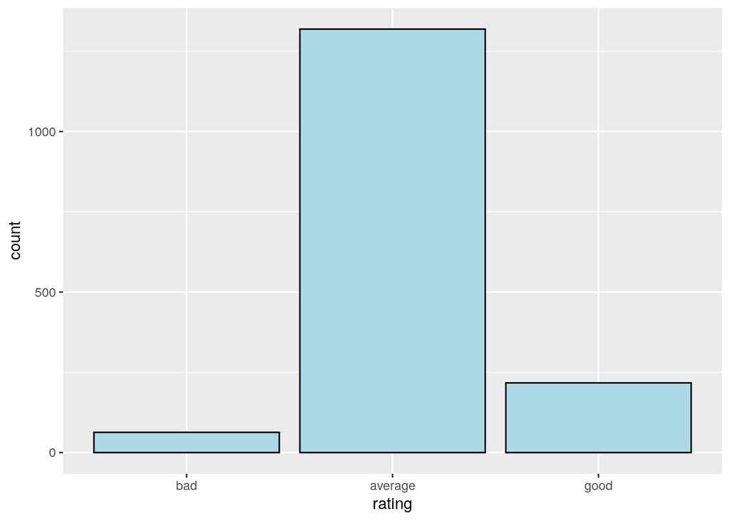

```r
rating_h<-ggplot(aes(x=rating,color = I('black'),fill=I('lightblue')), data = red_wine ) +
  geom_histogram( stat = "count")
rating_h
```

To understand the data more, and have a look at the type of distribution and outliers, graphs are visualized to demonstrate statistical information.

```r
# Distribution of fixed.acidity variable.

#it shows that there is one peak at 7 in the histogram plot.and it has outliers

summary(red_wine$fixed.acidity)
```

```
## Length  Class   Mode
##      0   NULL   NULL
```

```r
fixed_acidity_h<-ggplot(aes(x=fixed.acidity,color = I('black'),fill=I('lightblue')), data = red_wine ) +
  geom_histogram()
fixed_acidity_h
```

```
## Error in `check_aesthetics()`:
## ! Aesthetics must be either length 1 or the same as the data (1599): x
```

```r
# Distribution of citric acid variable
#it shows that there are two peaks at 0 and 0.49 in the histogram plot.and it has outliers
#we can see that citric.acid has an outlier
summary(red_wine$citric.acid)
```

```
## Length  Class   Mode
##      0   NULL   NULL
```

```r
citric_acid_h <-ggplot(aes(x=citric.acid,color = I('black'),fill=I('lightblue')), data = red_wine ) +
  geom_histogram()


# Distribution of volatile.acidity
#it shows that there are two peaks at 0.6 and 0.4 in the histogram plot.and it has outliers
summary(red_wine$volatile.acidity)
```

```
## Length  Class   Mode
##      0   NULL   NULL
```

```r
volatile_acidity_h <-ggplot(aes(x=volatile.acidity,color = I('black'),fill=I('lightblue')), data = red_wine ) +
  geom_histogram()



#Distribution of residual.sugar
#it shows one peak at 2. and it has an outliers
summary(red_wine$residual.sugar)
```

```
## Length  Class   Mode
##      0   NULL   NULL
```

```r
residual_sugar_h <-ggplot(aes(x=residual.sugar,color = I('black'),fill=I('lightblue')), data = red_wine ) +
  geom_histogram()


# Distribution of chlorides
#it shows one peak at 0.08. and it has an outliers
summary(red_wine$chlorides)
```

```
##    Min. 1st Qu.  Median    Mean 3rd Qu.    Max.
## 0.01200 0.07000 0.07900 0.08747 0.09000 0.61100
```

```r
chlorides_h <-ggplot(aes(x=chlorides,color = I('black'),fill=I('lightblue')), data = red_wine ) +
  geom_histogram()



# Distribution of free.sulfur.dioxide
#it shows one peak at 5. and it has an outliers and it shows a normal distribution
summary(red_wine$free.sulfur.dioxide)
```

```
## Length  Class   Mode
##      0   NULL   NULL
```

```r
free_sulfur_dioxide_h <-ggplot(aes(x=free.sulfur.dioxide,color = I('black'),fill=I('lightblue')), data = red_wine ) +
  geom_histogram()



# Distribution of density
#it shows one peak at #it shows one peak at 0.99. and it has an outliers
#The summary results shows that the mean and median values
#are pretty close which means we have a normal distribution .
summary(red_wine$density)
```

```
##    Min. 1st Qu.  Median    Mean 3rd Qu.    Max.
##  0.9901  0.9956  0.9968  0.9967  0.9978  1.0037
```

```r
density_h<-ggplot(aes(x=density,color = I('black'),fill=I('lightblue')), data = red_wine ) +
  geom_histogram()


# Distribution of total.sulfur.dioxide
#it shows that it has a peak value around 20. and it has an outliers
summary(red_wine$total.sulfur.dioxide)
```

```
## Length  Class   Mode
##      0   NULL   NULL
```

```r
total_sulfur_dioxide_h<-ggplot(aes(x=total.sulfur.dioxide,color = I('black'),fill=I('lightblue')), data = red_wine ) +
  geom_histogram()



# Distribution of pH
#The summary results shows that the mean and median values
#are pretty close which means we have a normal distribution .
summary(red_wine$pH)
```

```
## Length  Class   Mode
##      0   NULL   NULL
```

```r
pH_h <-ggplot(aes(x=pH,color = I('black'),fill=I('lightblue')), data = red_wine ) +
  geom_histogram()


# Distribution of sulphates
#it shows that it has a peak value around 0.6.and it has an outliers
summary(red_wine$sulphates)
```

```
##    Min. 1st Qu.  Median    Mean 3rd Qu.    Max.
##  0.3300  0.5500  0.6200  0.6581  0.7300  2.0000
```

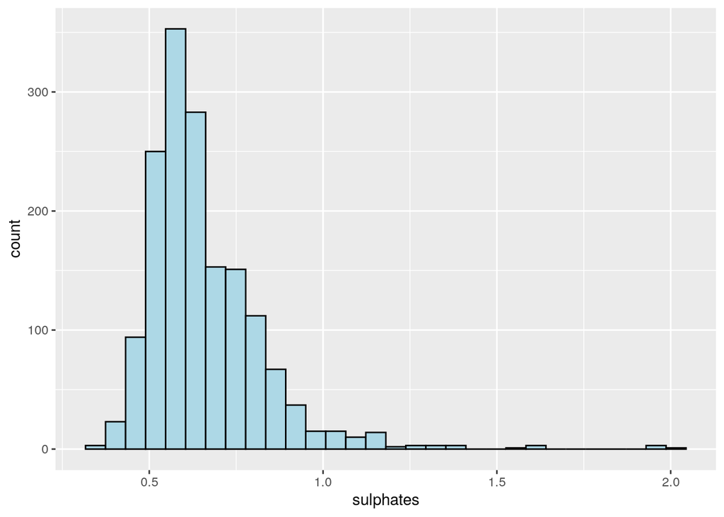

```r
sulphates_h<-ggplot(aes(x=sulphates,color = I('black'),fill=I('lightblue')), data = red_wine ) +
  geom_histogram()

sulphates_h
```

```r
# Distribution of alcohol
#it shows that it has a peak value around 9.4. and it has an outliers
summary(red_wine$alcohol)
```

```
##    Min. 1st Qu.  Median    Mean 3rd Qu.    Max.
##    8.40    9.50   10.20   10.42   11.10   14.90
```

```r
alcohol_h<-ggplot(aes(x=alcohol,color = I('black'),fill=I('lightblue')), data = red_wine ) +
  geom_histogram()

# Distribution of quality
#it shows that there are two peaks at 5 and 6 in the histogram plot.
summary(red_wine$quality)
```

```
##   3   4   5   6   7   8
##  10  53 681 638 199  18
```

```r
quality_h<-ggplot(aes(x=quality,color = I('black'),fill=I('lightblue')), data = red_wine ) +
  geom_histogram(stat="count")
# Distribution of rating
#the distribution shows that most of the wines falls under the average wine quality.
summary(red_wine$rating)
```

```
##     bad average    good
##      63    1319     217
```

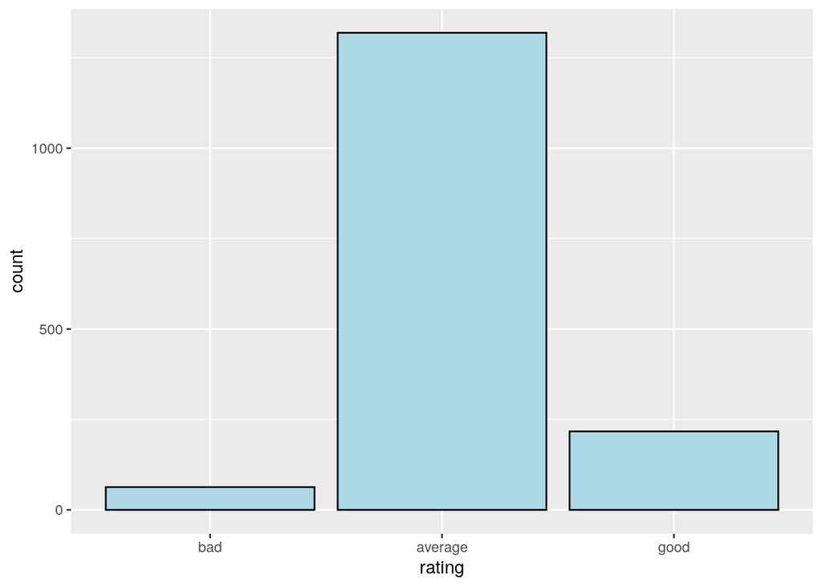

```r
rating_h<-ggplot(aes(x=rating,color = I('black'),fill=I('lightblue')), data = red_wine ) +
  geom_histogram( stat = "count")
rating_h
```

```r
#now use grid.arrange function
grid.arrange(fixed_acidity_h,volatile_acidity_h,citric_acid_h,
             residual_sugar_h,chlorides_h,free_sulfur_dioxide_h,
             total_sulfur_dioxide_h,density_h,pH_h,
             alcohol_h,ncol=2 ,bottom = "Variables Distributions ")
```

```
## Error in `check_aesthetics()`:
## ! Aesthetics must be either length 1 or the same as the data (1599): x
```

we can use the aggregate function for the data set and group it by “rating” by computing the mean for each group

```r
agg_mean<-aggregate(red_wine[,1:12],by=list(red_wine$rating),FUN=mean, na.rm=TRUE)
agg_mean
```

```
##   Group.1 fixed_acidity volatile_acidity citric_acid residual_sugar  chlorides
## 1     bad      7.871429        0.7242063   0.1736508       2.684921 0.09573016
## 2 average      8.254284        0.5385595   0.2582638       2.503867 0.08897271
## 3    good      8.847005        0.4055300   0.3764977       2.708756 0.07591244
##   free_sulfur_dioxide total_sulfur_dioxide   density      p_h sulphates
## 1            12.06349             34.44444 0.9966887 3.384127 0.5922222
## 2            16.36846             48.94693 0.9968673 3.311296 0.6472631
## 3            13.98157             34.88940 0.9960303 3.288802 0.7434562
##    alcohol quality
## 1 10.21587      NA
## 2 10.25272      NA
## 3 11.51805      NA
```

#### Correlation:

Now we compare alchool with the rest of variables based on the ratings to see which variable is compatible with alchool that gives a good wine quality and interpret only the good rating.

#####fixed.acidity: